# Assignment answers

2023-12-09

## How to use this document:

This HTML contains my code, and the answers to the assignment questions.

However, if you want to be able to run the code yourself, visit my GitHub repository and follow the instructions provided: https://github.com/lb23092/Reproducible_figures_R.git

## QUESTION 01: Data Visualisation for Science Communication

### Create a figure using the Palmer Penguin dataset that is correct but badly communicates the data.

For this question, I decided to create a misleading scatter plot with Culmen depth on the x-axis, and Body mass on the y-axis. Here are the steps for this analysis:

Firstly, I had to install and load the relevant packages:

Installing packages:

```r
#install.packages("palmer penguins")
#install.packages("ggplot2")
#install.packages("janitor")
#install.packages("dplyr")
#install.packages("tinytex")
#install.packages("knitr")
#install.packages("rmarkdown")
#install.packages("tinytex")
```

Attaching packages:

```r
library(palmerpenguins)
library(ggplot2)
library(janitor)
library(dplyr)
library(tinytex)
library(knitr)
library(rmarkdown)
library(tinytex)
```

This code can be run to create a file containing information about the packages I used for the analysis. If you come across an issue when running my code, this can be checked to make sure its not because of discrepancies in the versions being used. You can also find this information stored in the file `package_infromation.txt` of my packages folder.

```r
#sink("package_information.txt")
```

The data I used is already part of the Palmer Penguins package. However, it may be useful to save a version of this raw data to your directory. This code creates a folder called “data” and within it, a file containing the raw data. Although not a necessary step, the final line can be used to create a raw data object in your own environment.

```r
dir.create("data")
write.csv(penguins_raw, "data/penguins_raw.csv")

penguins_raw <- penguins_raw
```

Next, the data needs to be cleaned, and “clean_names()”, a function in janitor, can help to do this. It is designed to make column names more consistent by converting them to lowercase, removing special characters and replacing spaces with underscores. Additionally, “filter” is used in this instance to select for rows that contain values for both culmen depth and body mass, and select is to isolate these columns.

```r
penguins_clean_Q1 <- penguins_raw %>%
  clean_names() %>%
  filter(complete.cases(culmen_depth_mm, body_mass_g)) %>%
  select(species, culmen_depth_mm, body_mass_g)
```

Next, it is important to save this cleaned data as a file. This code saves it to our “data” folder:

```r
write.csv(penguins_clean_Q1, "data/penguins_clean_Q1")
```

### My misleading figure

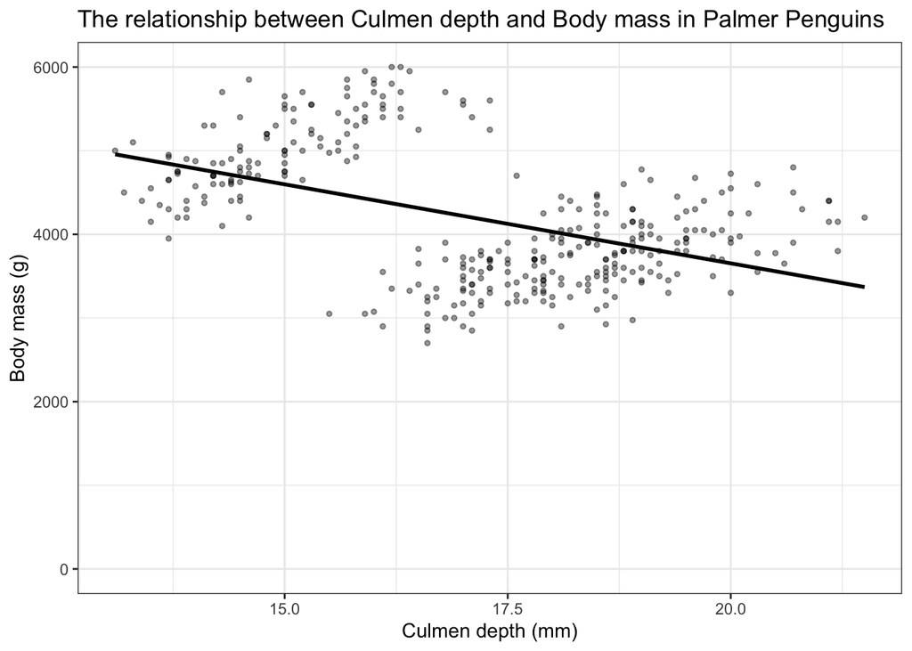

A better figure, which splits the relationship by species, can be produced using:

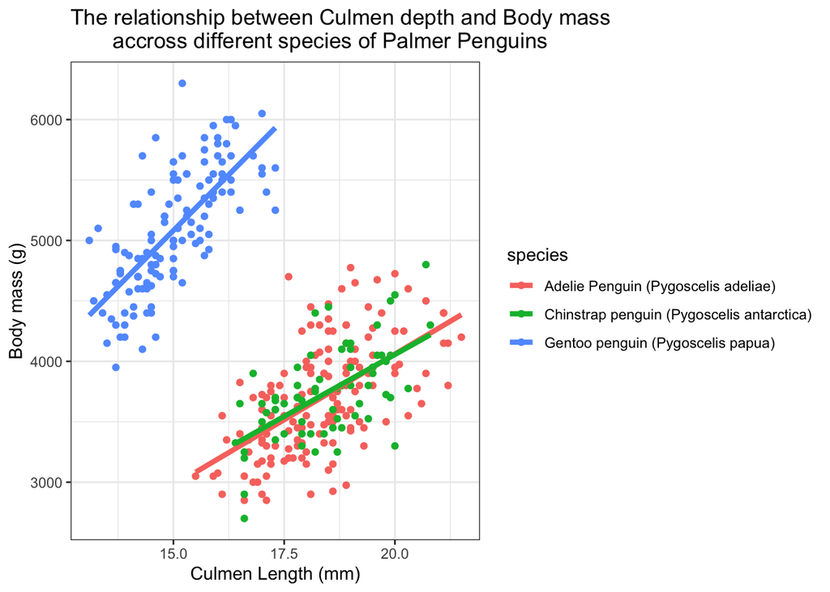

```r
improved_graph <- ggplot(penguins_clean_Q1, aes(x = culmen_depth_mm, y = body_mass_g, color = species)) +
  geom_point() +
  geom_smooth(method = "lm", se = FALSE, size = 1.5) +
  labs(x = "Culmen Length (mm)", y = "Body mass (g)", title = "The relationship between Culmen depth and Body mass
       accross different species of Palmer Penguins") +
  theme_bw()
improved_graph
```

You can save these figures as PNGs using the code:

```r
ggsave("figures/Q1_misleading_graph.png", plot = misleading_graph, width = 8, height = 6, units = "in")
ggsave("figures/Q1_improved_graph.jpg", plot = improved_graph, width = 8, height = 6, units = "in")
```

## QUESTION 2: Data Pipeline

### Write a data analysis pipeline in your .rmd RMarkdown file. You should be aiming to write a clear explanation of the steps, the figures visible, as well as clear code.*

### Introduction

In this analysis, I want to find out whether a statistically significant linear relationship exists between Culmen length and Body mass. If such a relationship is established it shows that there is a systematic association between the two variables, meaning that there is a degree of power in being able to predict one variable from another. This could be very useful to scientists, especially given that body mass is often practically challenging to measure in penguins. Furthermore, the relationship between the variables could provide interesting biological insights. For example, if the relationship is positive, it may suggest that having a larger beak facilitates more successful feeding therefore allowing the penguin to sustain a higher body mass. It is important to note that whilst sub-setting by species may provide a result with higher statistical significance, I believe that a model like mine would be more generalizable. For example, if a researcher has a penguin that is not one of these three species, mine model will be preferred as it takes into account more species. My analysis is carried out using data stored in the “Palmer Penguin” package.

Before using the data, it must be cleaned. I have already created a file containing useful functions and their descriptions in my “functions” folder, and some of these can be used in this step. The function `source()` is included to retrieve them:

```r
source("functions/assignment_functions.r")

penguins_clean_Q2 <- penguins_raw  %>%
    clean_column_names() %>%
    shorten_species() %>%
    remove_empty_columns_rows() %>%
   remove_NA()
```

Next, it is important to save this cleaned data as a file. This code saves it to our “data” folder:

```r
write.csv(penguins_clean_Q2, "data/penguins_clean_Q2")
```

This code and the function it contains, uses the cleaned data to produce a graph of the relationship between Culmen length and Body Mass:

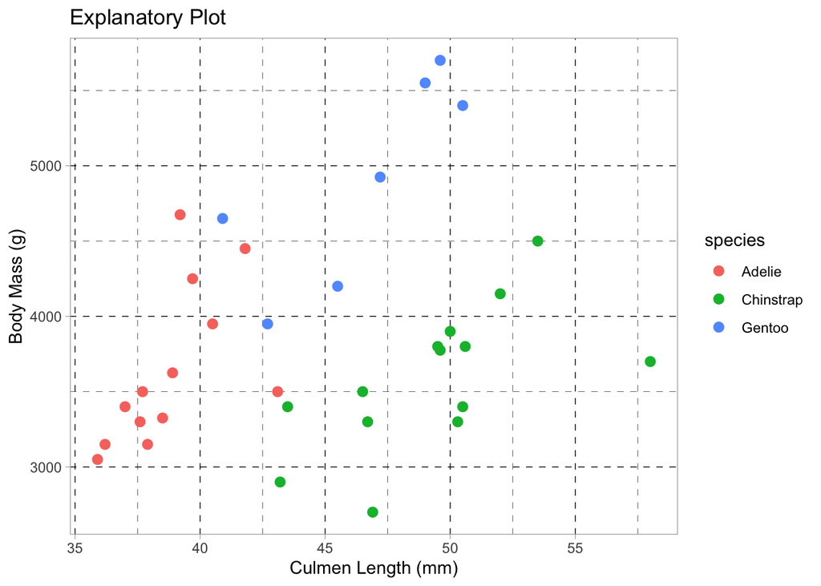

```r
explanatory_plot <-explanatory_plot(penguins_clean_Q2)
explanatory_plot
```

We can save the figure as a PNG using this code:

```r
ggsave("figures/Q2_exploratory_plot.png", plot = explanatory_plot, width = 8, height = 6, units = "in")
```

### Hypothesis

- H<sub>0</sub> (null hypothesis): there is no statistically significant linear relationship between Culmen length and Body mass for Palmer Penguins (aka. slope β = 0)
- H<sub>A</sub> (alternative hypothesis): there is a statistically significant linear relationship between Culmen length and Body mass for Palmer Penguins (aka. slope β ≠ 0)

### Statistical Methods

To be able carry out linear regression analysis, multiple assumptions must be met. One of the most important is that the residuals (the differences between the observed values and the values predicted by the regression model) should follow a normal distribution. For my statistical method therefore, I decided to test this assumption in two ways: 1) by carrying out the Shapiro-Wilk test, and 2) by producing a Quantile-Quantile (Q-Q plot).

Before testing the normal distribution assumption, you first have to run the linear regression to obtain the residual data. The function `lm()` can be used to do this:

```r
linear_model_culmen_length_body_mass <- lm(body_mass_g ~ culmen_length_mm, data = penguins_clean_Q2)
summary(linear_model_culmen_length_body_mass)
```

```
##
## Call:
## lm(formula = body_mass_g ~ culmen_length_mm, data = penguins_clean_Q2)
##
## Residuals:
##     Min      1Q  Median      3Q     Max
## -1268.6  -438.7  -237.6   281.4  1618.7
##
## Coefficients:
##                  Estimate Std. Error t value Pr(>|t|)
## (Intercept)       2010.15     971.18   2.070   0.0466 *
## culmen_length_mm    41.76      21.55   1.938   0.0615 .
## ---
## Signif. codes:  0 '***' 0.001 '**' 0.01 '*' 0.05 '.' 0.1 ' ' 1
##
## Residual standard error: 717.9 on 32 degrees of freedom
## Multiple R-squared:  0.1051, Adjusted R-squared:  0.07709
## F-statistic: 3.756 on 1 and 32 DF,  p-value: 0.06148
```

Now we have the linear model, we can run the Shapiro-Wilk test using the `Shapiro.test()` function:

```r
shapiro_test_results <- shapiro.test(residuals(linear_model_culmen_length_body_mass))
shapiro_test_results
```

```
##
##  Shapiro-Wilk normality test
##
## data:  residuals(linear_model_culmen_length_body_mass)
## W = 0.93571, p-value = 0.04601
```

The Shapiro-Wilk test is used to test a null hypothesis that the data is normally distributed. Therefore, given that our p-value is <0.05, we have to reject it. Ultimately, this has shown that the residuals are not normally distributed.

Now we want to see whether the Quantile-Quantile plot produces the same result. The functions `qqnorm()` and `qqline()` can be used to produce it:

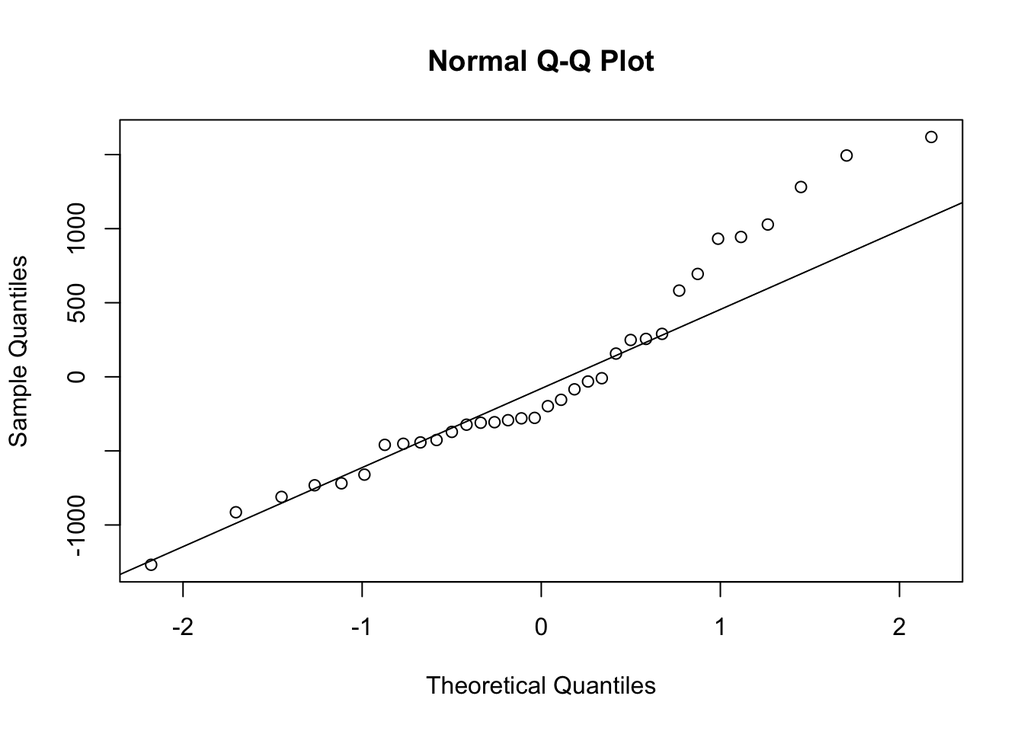

```r
qqnorm(residuals(linear_model_culmen_length_body_mass))
qqline(residuals(linear_model_culmen_length_body_mass))
```

In a Q-Q plot, the closer the data points sit to the line, the closer the residuals follow a normal distribution. So therefore, given that the points do not follow the line exactly, we have to assume that our residuals are not normal. This supports the result of the Shapiro-Wilk test.

Given that both of my tests revealed that the residuals are not normally distributed, we cannot carry out linear regression analysis on the data as it is at the moment. For this reason, we must apply a transformation to try and make them normal. I decided to take the natural log (ln) of both variables, by incorporating log() into my model:

```r
linear_model_culmen_length_body_mass_transformed <- lm((log(body_mass_g)) ~ (log(culmen_length_mm)), data = penguins_clean_Q2)
summary(linear_model_culmen_length_body_mass_transformed)
```

```
##
## Call:
## lm(formula = (log(body_mass_g)) ~ (log(culmen_length_mm)), data = penguins_clean_Q2)
##
## Residuals:
##      Min       1Q   Median       3Q      Max
## -0.37159 -0.10733 -0.04490  0.08315  0.34900
##
## Coefficients:
##                       Estimate Std. Error t value Pr(>|t|)
## (Intercept)             6.4427     0.8943   7.204 3.51e-08 ***
## log(culmen_length_mm)   0.4755     0.2357   2.018   0.0521 .
## ---
## Signif. codes:  0 '***' 0.001 '**' 0.01 '*' 0.05 '.' 0.1 ' ' 1
##
## Residual standard error: 0.1759 on 32 degrees of freedom
## Multiple R-squared:  0.1129, Adjusted R-squared:  0.08513
## F-statistic: 4.071 on 1 and 32 DF,  p-value: 0.05209
```

The code to re-do these tests using the transformed linear model:

```r
shapiro_test_results_transformed <- shapiro.test(residuals(linear_model_culmen_length_body_mass_transformed))
shapiro_test_results_transformed
```

```
##
##  Shapiro-Wilk normality test
##
## data:  residuals(linear_model_culmen_length_body_mass_transformed)
## W = 0.96143, p-value = 0.2675
```

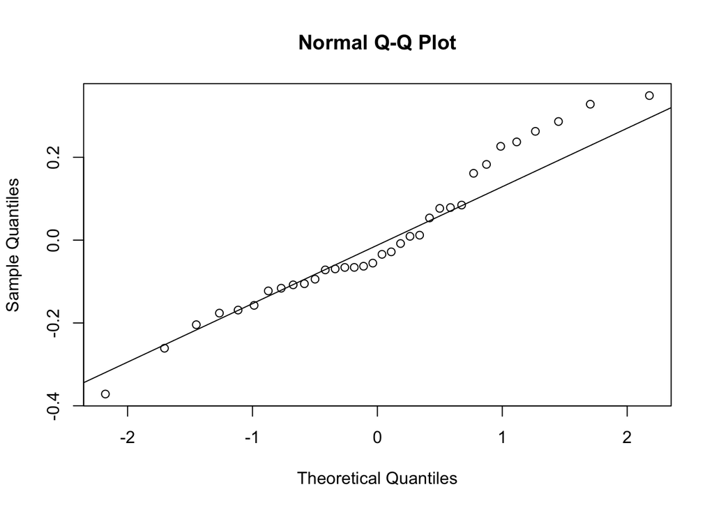

```r
transformed_qqplot <-qqnorm(residuals(linear_model_culmen_length_body_mass_transformed))
qqline(residuals(linear_model_culmen_length_body_mass_transformed))
```

As you can see, the transformation has worked successfully given that a) the p value of the Shapiro-Wilk test is now above 0.05, and b) the points on the Q-Q plot now follow the line more closely. So the new transformed linear regression’s residuals are now normally distributed.

Finally, we must back-transform the results of the linear regression, in order to obtain the actual parameter estimates:

```r
final_intercept <- exp(6.4427)
final_slope <- exp(0.4755)

final_intercept
```

```
## [1] 628.1004
```

```r
final_slope
```

```
## [1] 1.608818
```

I created a final figure for my results, by inputting the cleaned data into my pre-defined function final_linear_model_plot(). Remember, that on this graph, the two variables have been log-transformed:

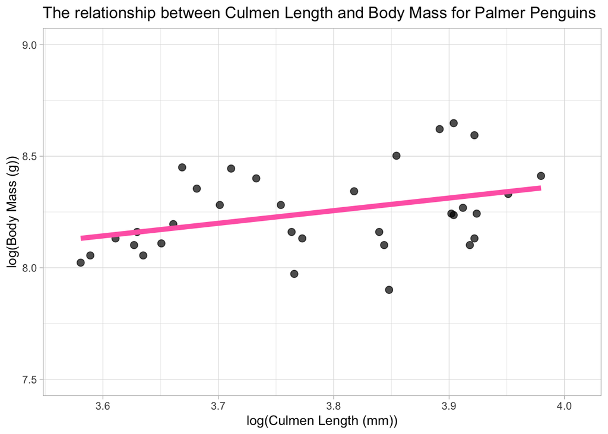

```r
source("functions/assignment_functions.r")
final_linear_model_plot(penguins_clean_Q2)
```

```r
final_linear_model_plot
```

```
## function (cleaned_data)
## {
##     ggplot(cleaned_data, aes(x = log(culmen_length_mm), y = log(body_mass_g))) +
##         geom_point(size = 2.5, alpha = 0.7) + geom_smooth(method = "lm",
##         se = FALSE, linewidth = 2, color = "hot pink") + ylim(7.5,
##         9) + xlim(3.57, 4.01) + labs(x = "log(Culmen Length (mm))",
##         y = "log(Body Mass (g))", title = "The relationship between Culmen Length and Body Mass for Palmer Penguins") +
##         theme_light()
## }
```

### Results & Discussion

**The results of my linear regression are:**

- Intercept = 628.1004 (p = 3.51e-08)
- Slope = 1.608818 (p = 0.0521 .)

**Interpretation:**

The fact that the intercept has a p-value of <0.05 means that the predicted value for Body mass is significantly different from zero when the value for Culmen length is zero. However, given that the slope has a p-value of >0.05 means that *the relationship between the two variables is not statistically significant.* The multiple R-squared of my model is 0.1129, this means that only 11.29% of the variation in body mass is explained by Culmen length. The higher this value the better, so overall, the model is not a great fit to the data. Perhaps this is not surprising however. As evident in my analysis, I simply fitted a model to the data as a whole, instead of sub-setting it into different species. As shown by my exploratory graph, the relationship within species appeared stronger than the overall trend, so testing linear regression on each individually could be worthwhile in the future. Furthermore, of course this analysis relies on the assumption that our variables *have* a linear relationship which may not be the case. So this should be carefully checked to ensure that another type of model (e.g. polynomial) wouldn’t be more appropriate.

### Conclusion

Overall, there is no significant relationship between Culmen length and body mass in Palmer Penguins generally, potentially suggesting that beak size does not impact eating habits. However, more complex analysis should be applied in the future to enhance the understanding of these variables further.

## QUESTION 3: Open Science

### a) GitHub

*My GitHub link:*

[*https://github.com/lb23092/Reproducible_figures_R.git*](https://github.com/lb23092/Reproducible_figures_R.git)

*Partner’s GitHub link:*

https://github.com/1066509/penguinProject_homework.git

### c) Reflect on your experience running their code. (300-500 words)

- *What elements of your partner’s code helped you to understand their data pipeline?*

  Within their project, they defined functions in separate files, and successfully called them into the code on their markdown file. Whenever they called them, they signposted to this file which was well-annotated so that you knew what each was doing [e.g. line 232]. Furthermore, whenever they apply a pipe, they displayed the output underneath by recalling the object name [e.g. line 282]. This meant that I was able to refer to the output to help me understand the code.
- *Did it run? Did you need to fix anything?*

  After creating a project from their repository as instructed by the README.md file, all the student’s code ran correctly without any errors. Therefore, nothing needed to be fixed.
- *What suggestions would you make for improving their code to make it more understandable or reproducible, and why?*

  In their introduction [line 207-209], although they mentioned ‘Palmer penguins’, they referred to it as the dataset. However, ‘Palmer penguins’ is actually the package in which the data set, ‘penguins_raw’ is stored. Making this clearer would allow you to better understand the rest of the code, because otherwise, you are left wondering where the object penguins_raw has come from. When filtering the data, on occasions, the annotations did not specify how exactly this was being done. Although it is perhaps intuitive from looking at the code what the functions were doing e.g. subset_columns() [line 294], specifying how you could edit it for different variables would enhance the reproducibility. More-detailed annotations would also be beneficial for the statistical tests. For example, for complex analysis such as ANOVA [line 356], I would struggle to apply the same function without knowing which variables to place where.
- *If you needed to alter your partner’s figure using their code, do you think that would be easy or difficult, and why?*

  When looking at the code they used to produce their figure, it was obvious that they used a pre-defined function. This informed me that I had to check their “plotting_homework.R” file to inspect the function parameters. Firstly, the fact that it was placed in a custom function immediately enhances reproducibility. Because, if I wanted to include it in my own work and edit it later, I would be able to do so by simply editing this master-function so that whenever it was ran, the changes would be applied. Saying this, within the separate file, further annotations explaining each stage of the pipeline would make it easier for me to re-use later with different variables and aesthetics. An improvement would be to include more function parameters, such as colour, labels, and title, rather than hard-coding these ggplot attributes. This makes it possible to reuse the plotting function several times within your main code, where you then specify the appearance you want.

### d) Reflect on your own code based on your experience with your partner’s code and their review of yours. (300-500 words)

For reference, here is the feedback I received from my partner:

*My partner clearly explained each step in detail, making the pipeline very easy to follow throughout. This included explaining why they were going to do each step, and also clearly explaining conclusions drawn from the data. The code in each chunk is also laid out clearly, with each object and function described by human understandable names and laid out in snake case. All required packages had lines of code to install them, meaning each step of the code ran, if you removed the hashtags and ran these lines. If there had been a mistake, it would have been easy to trace it back due to the format of the names used and the fact that the clean and raw has been stored.*

*To make the code more understandable, it might have been useful to include a line of code that runs the clean data object: penguins_clean_Q2 in line 168. This could be the head() function or names(), to see the changes which have been made to the dataset upon cleaning. A couple of the object names within the statistical methods section could also have been shortened to make the code more readable. Although they clearly explain what the object is showing, the explanation ahead of the code is able to do this alone, and making the object names shorter might have made it easier to interpret the lines of code.*

*To make the code more reproducible, it might have helped to have if/else statements for installation of the packages. This means that these lines of code can be run through and it doesn’t involve user effort of removing hashtags from the names of the packages they don’t have. Without removing these hashtags, users will not be able to install the packages, and therefore some packages may not be installed for them.*

My answers:

- *What improvements did they suggest, and do you agree?*

The key thing that I agree with is that I should have used functions such as head() and names() to display output for my cleaning pipelines. Without this, the changes I’m making to the dataset would be unclear to the reader. Although I did provide a brief description of the functions in my “assignment_functions.r”, this simply consisted of a title e.g. *“A function to make sure the species names are shortened”*. Therefore, to ensure full reproducibility, what each line does should have been specified in all of my functions. I also completely agree with their final suggestion of including *if/else* statements to install packages, as a way to minimize the user effort required to remove the hash tags. In fact, I was already impressed by their use of this before receiving this feedback, given that its a great way to ensure the packages are only installed if they haven’t been done so already.

- *What did you learn about writing code for other people?*

Firstly, I have learnt a plethora of techniques that can be used to enhance reproducibility. Notably, prior to carrying out this assignment, I had never pre-defined custom functions before. Now however, I understand that this extremely useful for reusing code where one uses different parameters in multiple locations. Storing functions in a separate file also allows you to make edits, and these alterations will then be applied every time you run them in your main code.Perhaps the most important thing I’ve discovered however is that you must clearly, and rigorously annotate everything; the steps involved in your analysis, the explanation of your logic, signposting to other files, plus you should provide detailed instructions of how to use and modify your functions and pipelines. What *you* think is obvious within the code, may not be obvious to the reader, and so you should assume very little prior knowledge.

The most interesting think that I’ve taken from this assignment, is that you learn the most about reproducibility when you study someone else’s work. When looking at and running my partner’s code, issues that I hadn’t previously spotted in my code became evident. For example, I realized that functions in general could be made more useful in some instances if you are able to add-in your own paramaters when calling, rather than doing so by editing the function file. By doing this, the same function can be used a wider range of different contexts. Saying this, increasing the complexity of functions in this way must be accompanied by more detailed documentation. This would involve annotating every line to explain what it does, plus including instructions for modification. Style guides provide agreed-upon standards on how exactly to format and detail code and annotations, making everyone’s code more consistent.

In conclusion, to be able to create reproducible code, you must be informed about the techniques available. I also believe that its important to be regularly reading the code of others in your field to pick up ideas that you can incorporate in your own work.